# DA 460 - Assignment 7

Marjorie Blanco

08 August, 2018

# Part 1 R: Introduction to Simple Linear Regression

```r
# Load the nc data set into our workspace.
download.file("http://www.openintro.org/stat/data/mlb11.RData", destfile = "mlb11.RData")
load("mlb11.RData")

mlb11$team <- NULL
```

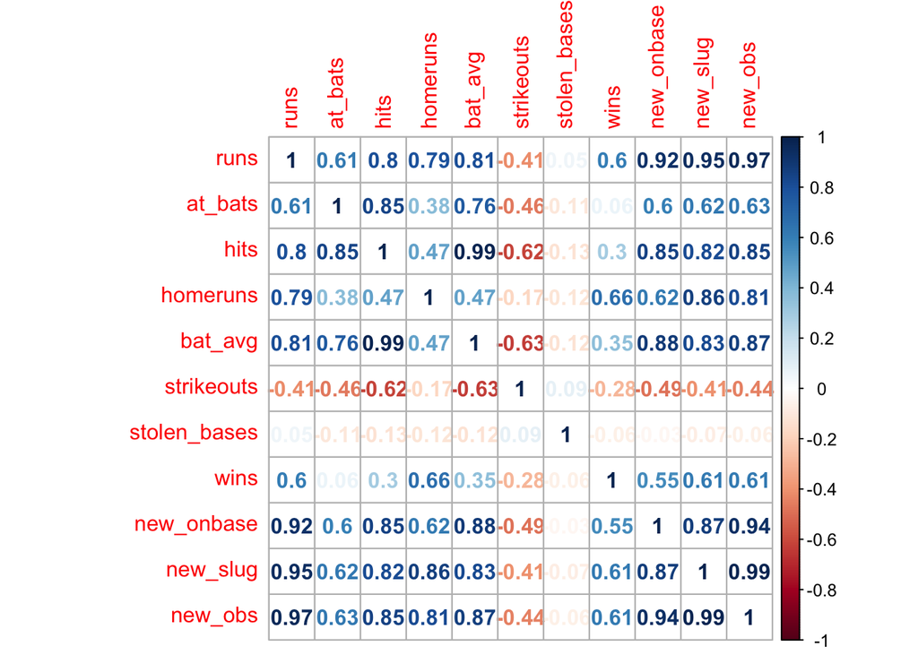

```r
corrplot(cor(mlb11), method = "number")
```

### Problem 1

Choose another traditional variable from `mlb11` that you think might be a good predictor of `runs`. Produce a scatterplot of the two variables and fit a linear model. At a glance, does there seem to be a linear relationship?

```r
fit0 <- lm(runs ~ bat_avg, data = mlb11)
summary(fit0)
```

```
##
## Call:
## lm(formula = runs ~ bat_avg, data = mlb11)
##
## Residuals:
##     Min      1Q  Median      3Q     Max
## -94.676 -26.303  -5.496  28.482 131.113
##
## Coefficients:
##             Estimate Std. Error t value Pr(>|t|)
## (Intercept)   -642.8      183.1  -3.511  0.00153 **
## bat_avg       5242.2      717.3   7.308 5.88e-08 ***
## ---
## Signif. codes:  0 '***' 0.001 '**' 0.01 '*' 0.05 '.' 0.1 ' ' 1
##
## Residual standard error: 49.23 on 28 degrees of freedom
## Multiple R-squared:  0.6561, Adjusted R-squared:  0.6438
## F-statistic: 53.41 on 1 and 28 DF,  p-value: 5.877e-08
```

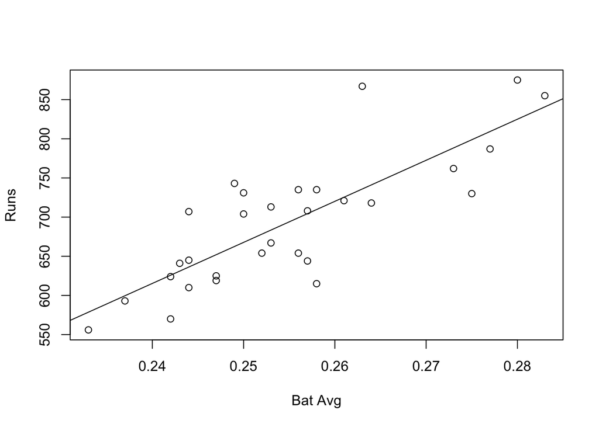

```r
plot(mlb11$runs~mlb11$bat_avg,
    xlab="Bat Avg",
    ylab="Runs")
abline(fit0)
```

```r
# quantify the strength of the relationship with the correlation coefficient
model_cor <- cor(mlb11$runs, mlb11$bat_avg)
model_cor
```

```
## [1] 0.8099859
```

The relationship between `bat_avg` and `runs` appears to be linear.

### Problem 2

How does this relationship compare to the relationship between `runs` and `at_bats`? Use the R2 values from the two model summaries to compare. Does your variable seem to predict `runs` better than `at_bats`? How can you tell?

```r
fit <- lm(runs ~ bat_avg, data = mlb11)
summary(fit)
```

```
##
## Call:
## lm(formula = runs ~ bat_avg, data = mlb11)
##
## Residuals:
##     Min      1Q  Median      3Q     Max
## -94.676 -26.303  -5.496  28.482 131.113
##
## Coefficients:
##             Estimate Std. Error t value Pr(>|t|)
## (Intercept)   -642.8      183.1  -3.511  0.00153 **
## bat_avg       5242.2      717.3   7.308 5.88e-08 ***
## ---
## Signif. codes:  0 '***' 0.001 '**' 0.01 '*' 0.05 '.' 0.1 ' ' 1
##
## Residual standard error: 49.23 on 28 degrees of freedom
## Multiple R-squared:  0.6561, Adjusted R-squared:  0.6438
## F-statistic: 53.41 on 1 and 28 DF,  p-value: 5.877e-08
```

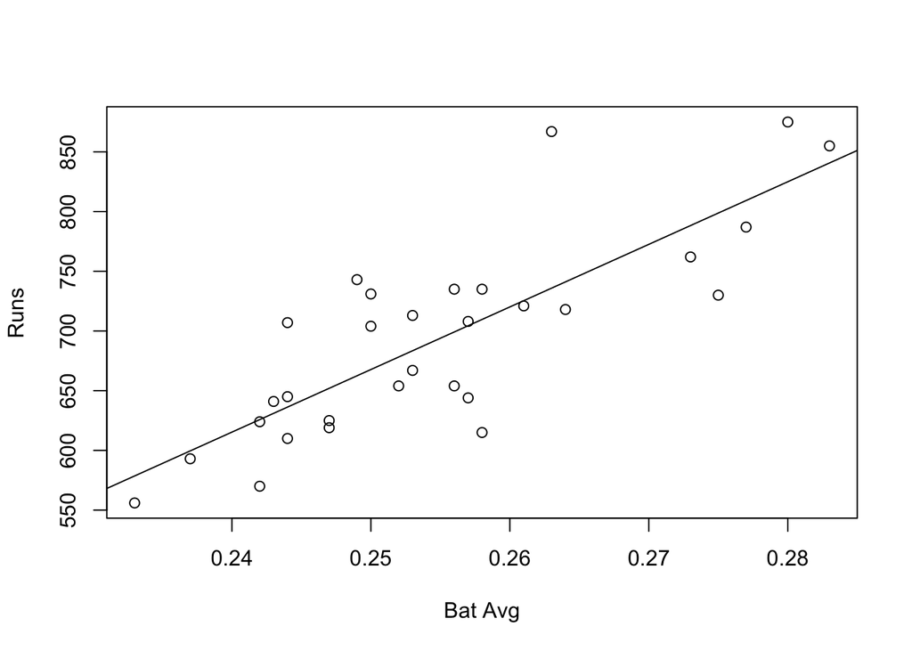

```r
plot(mlb11$runs ~ mlb11$bat_avg,
    xlab="Bat Avg",
    ylab="Runs")
abline(fit)
```

```r
summary(fit)$adj.r.squared
```

```
## [1] 0.6437942
```

The equation for the regression line is:

$$runs = 5242 * batavg - 643$$

```r
fit <- lm(runs ~ at_bats, data = mlb11)
summary(fit)
```

```
##
## Call:
## lm(formula = runs ~ at_bats, data = mlb11)
##
## Residuals:
##     Min      1Q  Median      3Q     Max
## -125.58  -47.05  -16.59   54.40  176.87
##
## Coefficients:
##               Estimate Std. Error t value Pr(>|t|)
## (Intercept) -2789.2429   853.6957  -3.267 0.002871 **
## at_bats         0.6305     0.1545   4.080 0.000339 ***
## ---
## Signif. codes:  0 '***' 0.001 '**' 0.01 '*' 0.05 '.' 0.1 ' ' 1
##
## Residual standard error: 66.47 on 28 degrees of freedom
## Multiple R-squared:  0.3729, Adjusted R-squared:  0.3505
## F-statistic: 16.65 on 1 and 28 DF,  p-value: 0.0003388
```

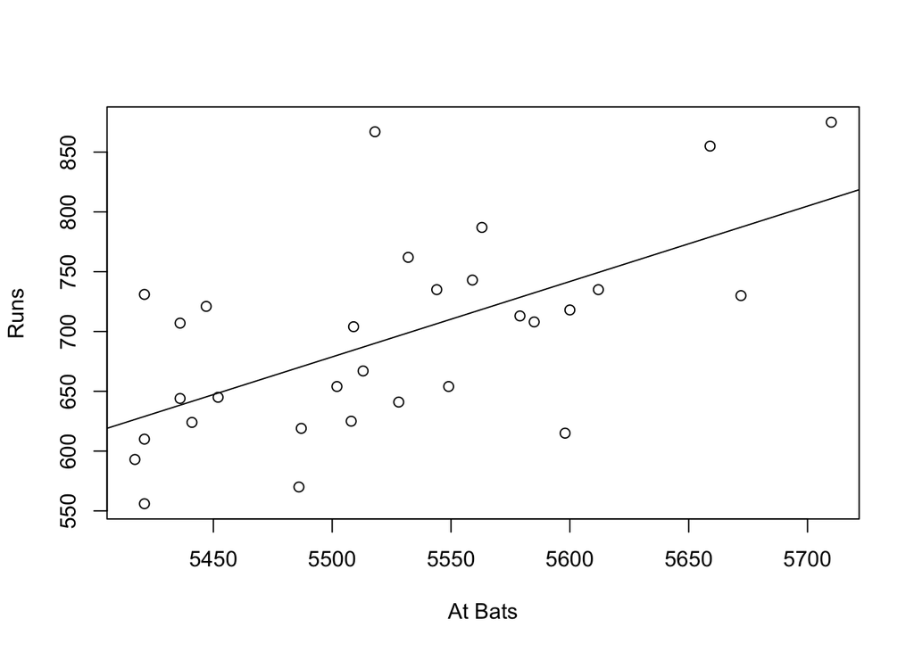

```r
plot(mlb11$runs ~ mlb11$at_bats,
    xlab="At Bats",
    ylab="Runs")
abline(fit)
```

```r
summary(fit)$adj.r.squared
```

```
## [1] 0.3504677
```

The equation for the regression line is:

$$runs = 0.631 * atbats - 2789.243$$

The R2 for `runs` and `at_bats` is `0.373`. This indicates that 37.3% of variability can be explained by the model. The R2 for `runs` and `bat_avg` is 0.656. This indicates that 65.6% of variability can be explained by the model. The variable bat_avg seem to predict `runs` better than `at_bats`.

### Problem 3

Now that you can summarize the linear relationship between two variables, investigate the relationships between runs and each of the other five traditional variables. Which variable best predicts runs? Support your conclusion using the graphical and numerical methods we’ve discussed (for the sake of conciseness, only include output for the best variable, not all five).

After reviewing summary statistics for all other traditional variables the best variable to predict `runs` is `bat_avg`. It has the highest R2.

### Problem 4

Now examine the three newer variables. These are the statistics used by the author of Moneyball to predict a team’s success. In general, are they more or less effective at predicting runs that the old variables? Explain using appropriate graphical and numerical evidence. Of all ten variables we’ve analyzed, which seems to be the best predictor of runs? Using the limited (or not so limited) information you know about these baseball statistics, does your result make sense?

The three newer variables are more effective at predicting `runs` that the old variables. The variable `new_obs` is the best predictor of `runs`. The `on base` makes sense as a good variable to predict `runs`. The higher the number of players are on base the higher the probablity to score a `run`.

```r
fit1 <- lm(runs ~ new_obs, data = mlb11)
summary(fit1)
```

```
##
## Call:
## lm(formula = runs ~ new_obs, data = mlb11)
##
## Residuals:
##     Min      1Q  Median      3Q     Max
## -43.456 -13.690   1.165  13.935  41.156
##
## Coefficients:
##             Estimate Std. Error t value Pr(>|t|)
## (Intercept)  -686.61      68.93  -9.962 1.05e-10 ***
## new_obs      1919.36      95.70  20.057  < 2e-16 ***
## ---
## Signif. codes:  0 '***' 0.001 '**' 0.01 '*' 0.05 '.' 0.1 ' ' 1
##
## Residual standard error: 21.41 on 28 degrees of freedom
## Multiple R-squared:  0.9349, Adjusted R-squared:  0.9326
## F-statistic: 402.3 on 1 and 28 DF,  p-value: < 2.2e-16
```

```r
fit2 <- lm(runs ~ new_slug, data = mlb11)
summary(fit2)
```

```
##
## Call:
## lm(formula = runs ~ new_slug, data = mlb11)
##
## Residuals:
##    Min     1Q Median     3Q    Max
## -45.41 -18.66  -0.91  16.29  52.29
##
## Coefficients:
##             Estimate Std. Error t value Pr(>|t|)
## (Intercept)  -375.80      68.71   -5.47 7.70e-06 ***
## new_slug     2681.33     171.83   15.61 2.42e-15 ***
## ---
## Signif. codes:  0 '***' 0.001 '**' 0.01 '*' 0.05 '.' 0.1 ' ' 1
##
## Residual standard error: 26.96 on 28 degrees of freedom
## Multiple R-squared:  0.8969, Adjusted R-squared:  0.8932
## F-statistic: 243.5 on 1 and 28 DF,  p-value: 2.42e-15
```

```r
fit3 <- lm(runs ~ new_onbase, data = mlb11)
summary(fit3)
```

```
##
## Call:
## lm(formula = runs ~ new_onbase, data = mlb11)
##
## Residuals:
##     Min      1Q  Median      3Q     Max
## -58.270 -18.335   3.249  19.520  69.002
##
## Coefficients:
##             Estimate Std. Error t value Pr(>|t|)
## (Intercept)  -1118.4      144.5  -7.741 1.97e-08 ***
## new_onbase    5654.3      450.5  12.552 5.12e-13 ***
## ---
## Signif. codes:  0 '***' 0.001 '**' 0.01 '*' 0.05 '.' 0.1 ' ' 1
##
## Residual standard error: 32.61 on 28 degrees of freedom
## Multiple R-squared:  0.8491, Adjusted R-squared:  0.8437
## F-statistic: 157.6 on 1 and 28 DF,  p-value: 5.116e-13
```

The equation for the regression line is:

$$runs = 1919.4 * new_obs - 686.6$$

$$runs = 2681.3 * new_slug - 375.8$$

Check the model diagnostics for the regression model with the variable you decided was the best predictor for `runs`.

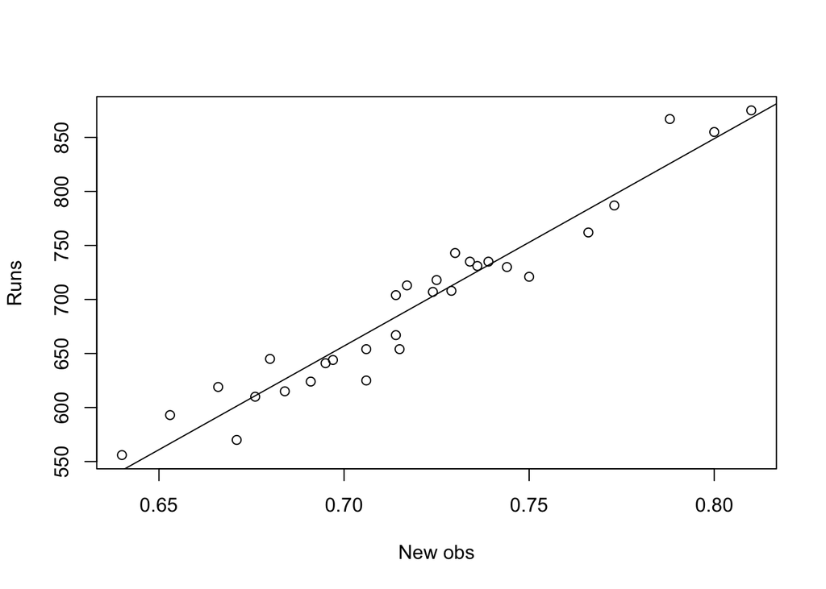

```r
plot(mlb11$runs~mlb11$new_obs,
    xlab="New obs",
    ylab="Runs")
abline(fit1)
```

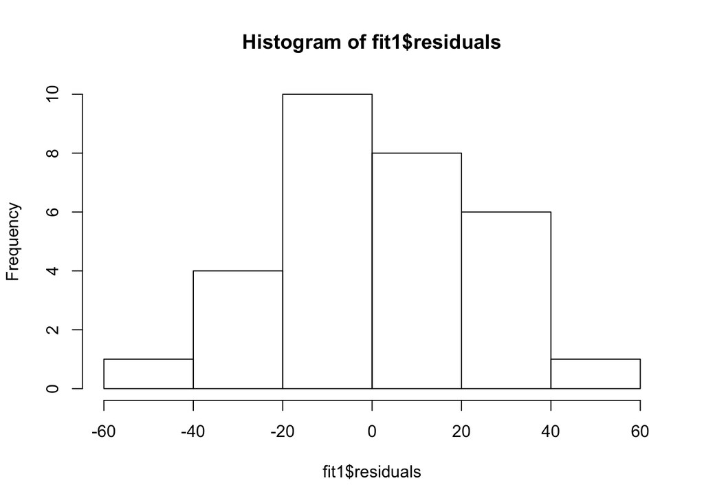

```r
hist(fit1$residuals)
```

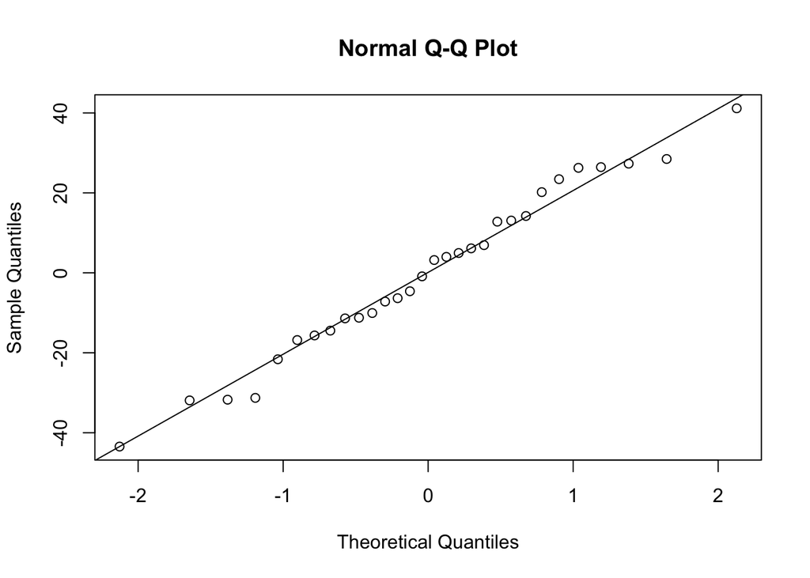

```r
qqnorm(fit1$residuals)
qqline(fit1$residuals)
```

Conditions for linear regression:

- Linearity

The regression plot shows many dots scattered closed to regression line. This assumption has been met.

- Normal residuals

The qq plot shows evidence of normality. Slightly left skewed distribution.

- Constant variability

There seems to have constant variability.